# Stan Lecture

Brody Erlandson

# About Stan

Stan is a probabilistic programming language that allows you to easily set up samplers for Bayesian inference. It is written in C++, so it will be faster (when doing the same sampler) than using base R. You should use Stan when you don’t have/want to create a unique sampler for a specific model, or when you want a quick implementation of a model before creating a sampler. Stan has a MCMC samplers and variational inference you can choose from, but this introduction will just show Hamiltonian Monte Carlo (HMC). Later in the course you will learn about how a different MCMC sampler works. For now we can just note that HMC does not require conjugacy nor a closed form posterior to use.

We can use Stan in R with `rstan`, which we can install with:

`install.packages("rstan", repos = c("https://mc-stan.org/r-packages/", getOption("repos")))`

# Problem set up

We will start with a simple problem:

$$\begin{aligned}
Y_1, \dots, Y_n|\theta &\overset{iid}{\sim} Pois(\theta) \\
\theta &\sim gamma(4, 1/2)
\end{aligned}$$

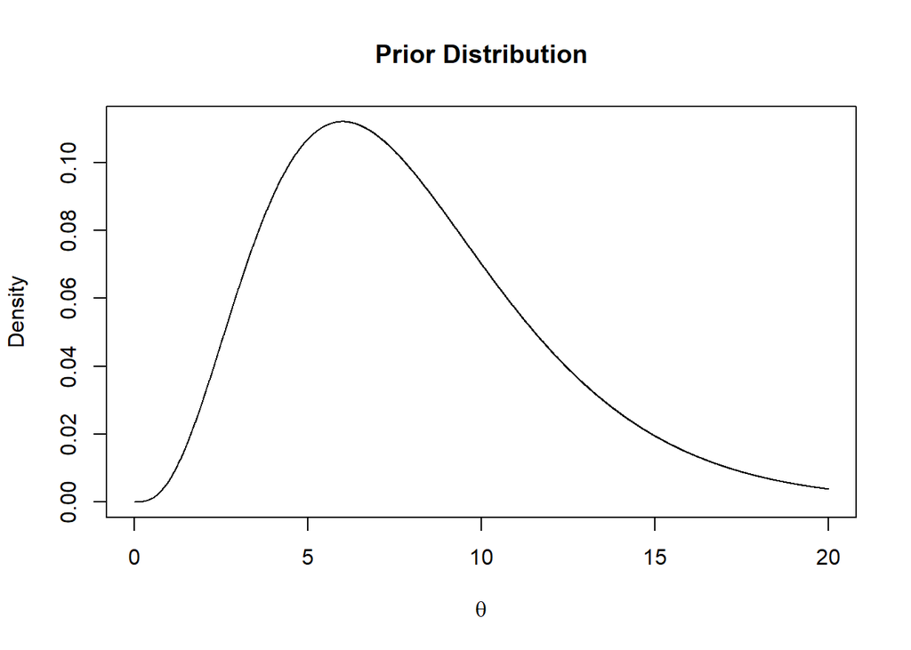

Note that this is a conjugate prior, so normally we would not use Stan, as it is a bit overboard for this problem. However, we are using this so that we can compare to what the actual posterior is. We will also look at a more complex example in a bit. First lets note the posterior distribution:

$$\theta|Y_1, \dots, Y_n \sim
gamma(4+\sum_{i=1}^ny_i, 1/2+n)$$

# Stan Set up

To use `rstan` we need to create a `.stan` file that tells stan what our model is. You can create this in a text file. Below is an outline of what it involves:

```
data {
  // declaration of variables that are read in as data (Knowns)
}
transformed data {
   // can transform data here if needed
}
parameters {
   // declarations of parameter (Unknows)
}
transformed parameters {
   // can transform parameters here if needed
}
model {
   // declaration of prior distribution and likelihood
}
generated quantities {
   // prediction and diagnotics
}
```

You can read in more depth [here](https://mc-stan.org/docs/reference-manual/blocks.html)

For our simple model we will use the following `.stan` file:

```
// saved as pois.stan
data {
  int<lower=1> n;               // Number of samples
  int<lower=0> y[n];            // Sample vector
  real<lower=0> alpha;          // First gamma prior parameter
  real<lower=0> beta;           // Second gamma prior parameter
}
parameters {
   real<lower=0> theta;         // Our parameter of interest
}
model {
   theta ~ gamma(alpha, beta);  // Prior
   y ~ poisson(theta);          // Likelihood
}
```

# Running our Model

Below we can see the code for the data set up and running the model with `rstan`:

```r
# Generating the data
n <- 300
y <- rpois(n, 7)

# Running rstan sampler
stanDat <- list(n = n, y = y,
                alpha=4, beta=.5) # setting up data for stan
stanFit <- stan(file = "pois.stan", # Stan file
                data = stanDat, # Data
                warmup = 500, # Number of iteration to burn-in
                iter = 1500, # Total number of iterations
                chains = 4) # Number of chains to run
```

After running the sampler we can get some summaries of the posterior:

```r
stanFit
```

```
## Inference for Stan model: anon_model.
## 4 chains, each with iter=1500; warmup=500; thin=1;
## post-warmup draws per chain=1000, total post-warmup draws=4000.
##
##          mean se_mean   sd    2.5%     25%     50%     75%   97.5% n_eff Rhat
## theta    6.81    0.00 0.15    6.53    6.71    6.81    6.92    7.12  1508    1
## lp__  1881.94    0.02 0.73 1879.85 1881.78 1882.22 1882.41 1882.46  1988    1
##
## Samples were drawn using NUTS(diag_e) at Wed Feb  1 11:40:09 2023.
## For each parameter, n_eff is a crude measure of effective sample size,
## and Rhat is the potential scale reduction factor on split chains (at
## convergence, Rhat=1).
```

We can also get the entire sample with `extract(stanFit)`, this would be useful if you wanted to make unique plots. Though the `rstan` library has some built in plotting that is useful for a quick look at whats going on.

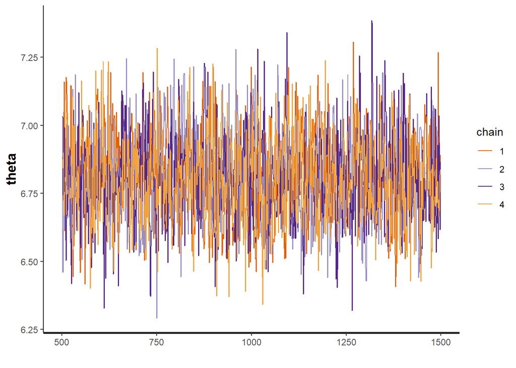

```r
traceplot(stanFit) # Check for convergence
```

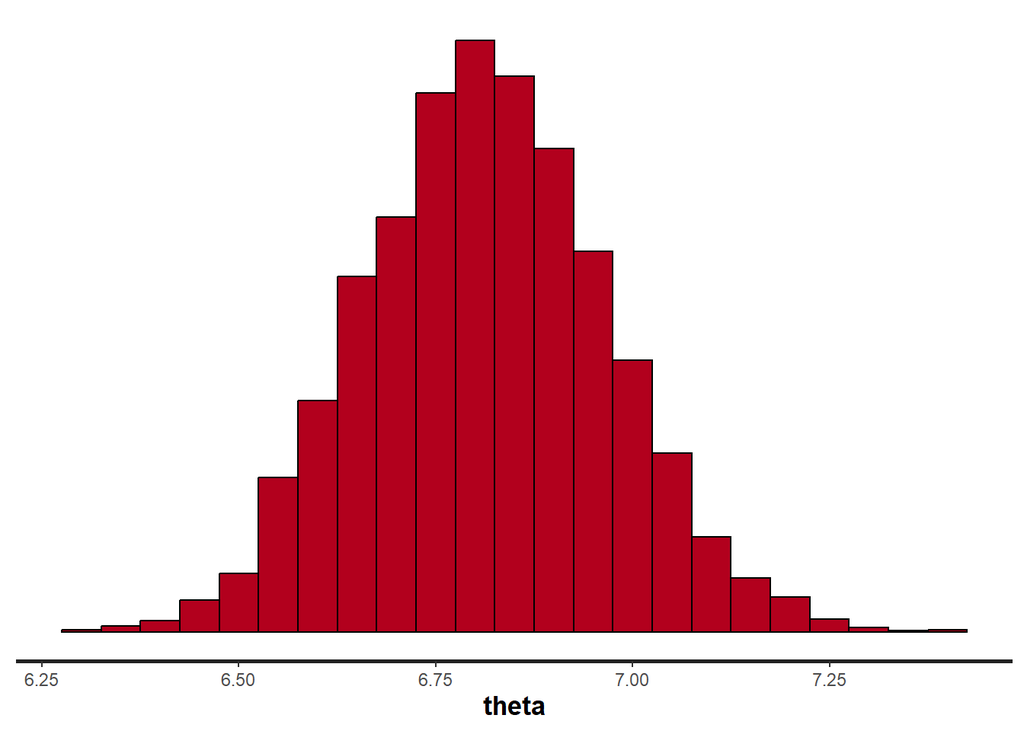

```r
stan_hist(stanFit, binwidth=.05)
```

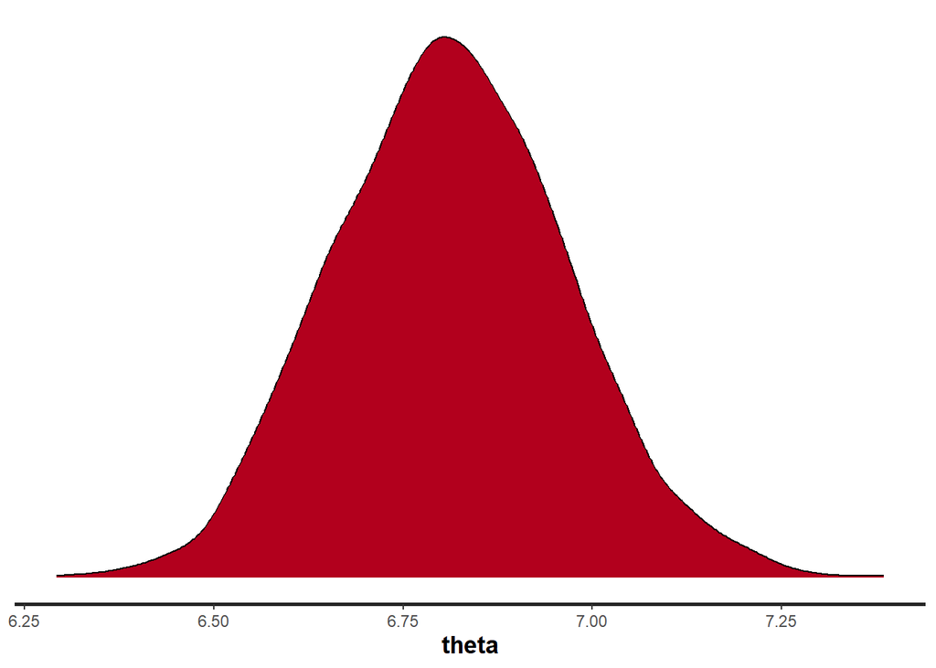

```r
stan_dens(stanFit)
```

Our actual posterior mean is 6.81, which is quite close to the estimated mean by the sampler. We can see the true posterior plotted below:

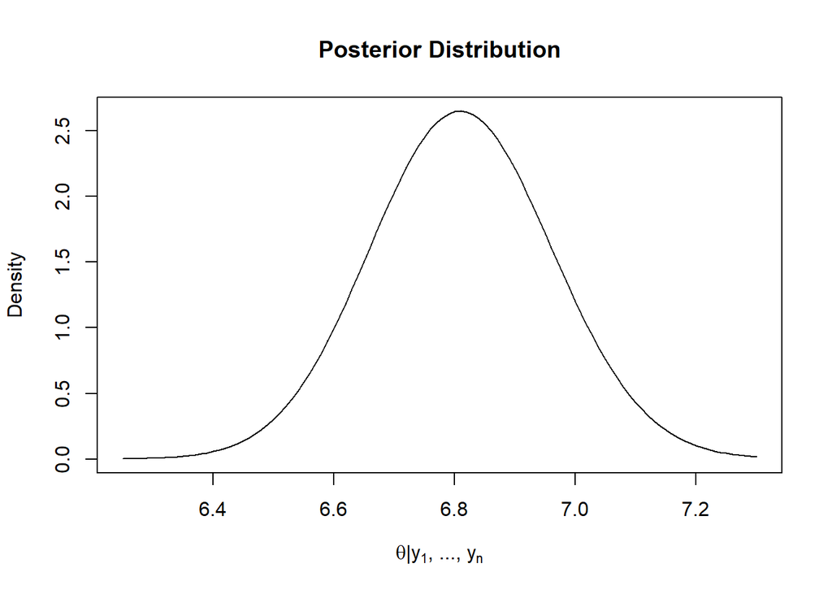

# More Complicated Example

This is a non-conjugate model, however we can still easily model with with Stan using the following:

```
// saved as norm.stan
data {
 int<lower = 1> n;     // Number of samples
 vector[n] y;          // Sample vector
 real df;              // Prior df
 real<lower=0> alpha;  // Prior scale
 real<lower=0> beta;   // Prior rate
}
parameters {
 real Theta;          // Mean unknow
 real <lower=0> Sig2; // variance unknow
}
model {
 // Priors:
 target += student_t_lpdf(Theta | df, 1, 1);    // lpdf is the log of the density
 target += gamma_lpdf(Sig2 | alpha, beta);

 // Likelihood:
 target += normal_lpdf(y | Theta, sqrt(Sig2));
}
```

Here are plots of the Priors:

[figure not shown]

Now we can set up the data and model to run:

```r
# Generating the data
n <- 500
y <- rnorm(n, 1.415, sqrt(2.718))

# Running rstan sampler
stanDat <- list(n = n, y = y, df=1,
                alpha=4, beta=1) # setting up data for stan
stanFit <- stan(file = "norm.stan", # Stan file
                data = stanDat, # Data
                warmup = 500, # Number of iteration to burn-in
                iter = 1500, # Total number of iterations
                chains = 4) # Number of chains to run
```

Again we can look at our summary output.

```r
stanFit
```

```
## Inference for Stan model: anon_model.
## 4 chains, each with iter=1500; warmup=500; thin=1;
## post-warmup draws per chain=1000, total post-warmup draws=4000.
##
##          mean se_mean   sd    2.5%     25%     50%     75%   97.5% n_eff Rhat
## Theta    1.41    0.00 0.08    1.26    1.36    1.41    1.46    1.56  2799    1
## Sig2     2.91    0.00 0.18    2.58    2.78    2.90    3.02    3.29  3687    1
## lp__  -976.42    0.02 0.99 -979.07 -976.79 -976.12 -975.71 -975.45  1736    1
##
## Samples were drawn using NUTS(diag_e) at Wed Feb  1 11:41:07 2023.
## For each parameter, n_eff is a crude measure of effective sample size,
## and Rhat is the potential scale reduction factor on split chains (at
## convergence, Rhat=1).
```

And we can look at the base plots again.

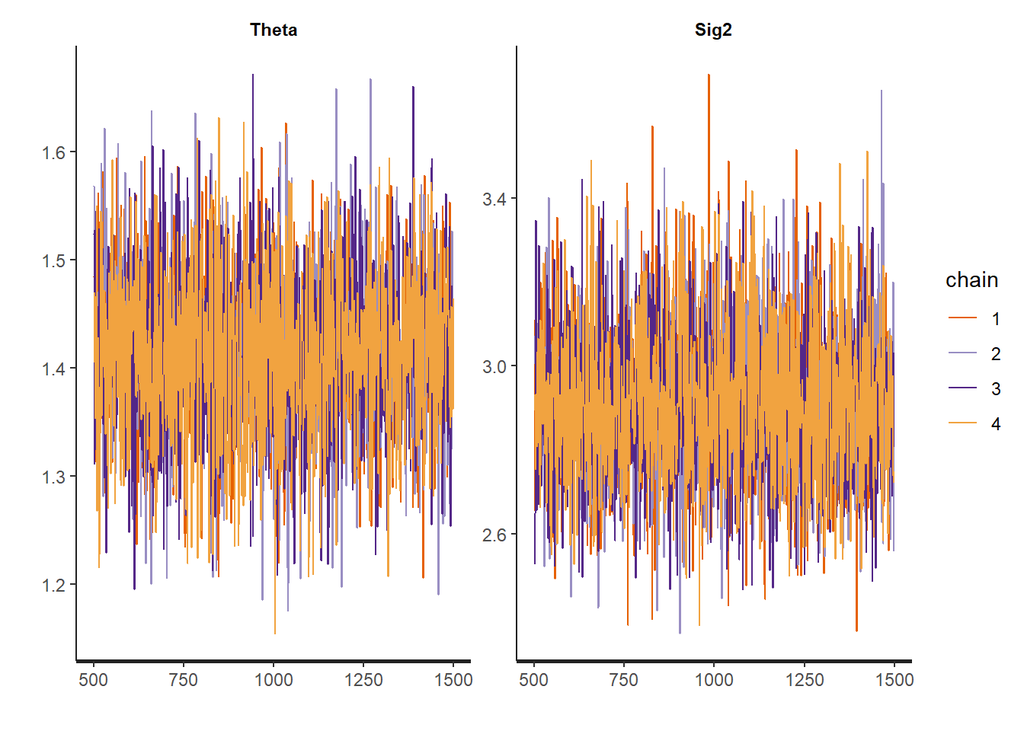

```r
traceplot(stanFit) # Check for convergence
```

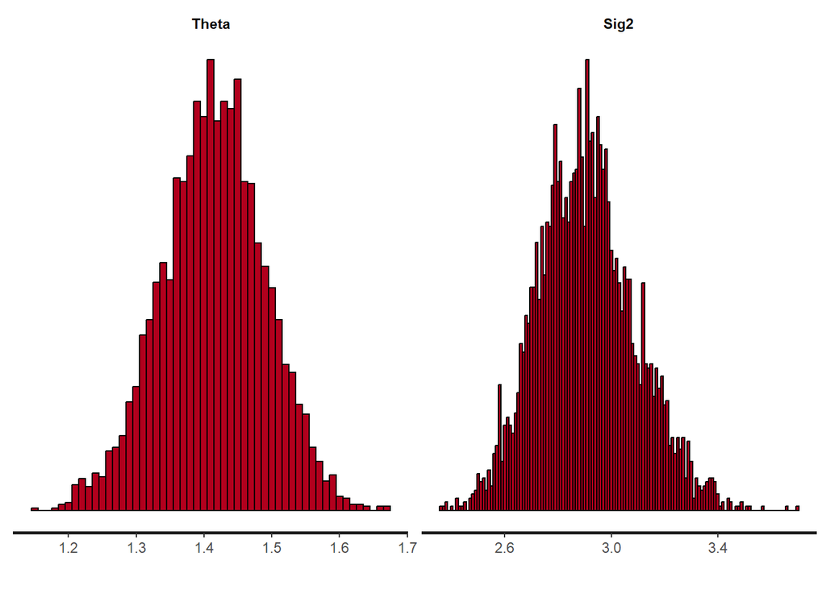

```r
stan_hist(stanFit, binwidth=.01)
```

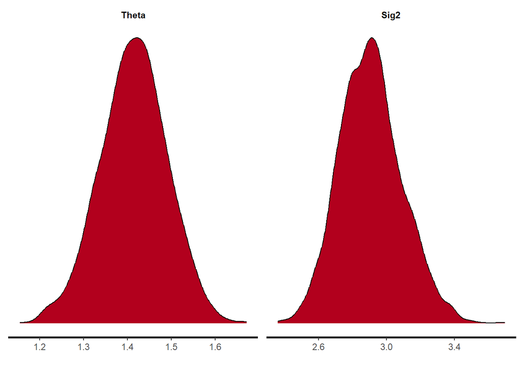

```r
stan_dens(stanFit)
```

# Resources and References

As you can image there is a lot more you can do. Below are some documentation links that should allow you to explore and gather what you need.

- [Stan Distributions](https://mc-stan.org/docs/functions-reference/continuous-distributions.html)
- [Stan Examples](https://mc-stan.org/docs/stan-users-guide/example-models.html#example-models.part)
- [rstan getting started](https://github.com/stan-dev/rstan/wiki/RStan-Getting-Started)
- [Stan blocks and general reference manual](https://mc-stan.org/docs/reference-manual/blocks.html)